# Investigacion Sobre las Universidades y sus Egresados

INTEGRANTES: Camila Gonzalez, Luciana Parallela, Camila Rondon, Mauricio Medina, Lucas Colosimo

Recolección De Datos y Análisis Primario de la Información

# INTRODUCCIÓN

### Introducción

Este trabajo utiliza datos del **Ministerio de Educación de la Nación Argentina**, extraídos de los Anuarios de Estadísticas Universitarias, y de una base complementaria proveniente de la **Encuesta sobre Condiciones de Ingreso a la Universidad (ECIU)**. Los datasets incluyen información sobre **ingresantes, reinscriptos y egresados** en universidades públicas y privadas del país, desagregada por *carrera, área disciplinar, género, edad, modalidad de estudio y situación laboral*. Estas fuentes permiten analizar los factores que influyen en la *tasa de egreso universitaria*, como el tipo de institución, la disciplina académica, y las condiciones socioeconómicas de los estudiantes

## Definición de los objetivos del analisis

La *problemática* que hemos elegido para el presente trabajo se basa en los factores que hacen que haya menor o mayor tasa de egresados en las universidades de Buenos Aires. En base a esta problemática y a partir de los data sets seleccionados y a su respectivo análisis, hemos elegido los siguientes factores a analizar:

- Cuál es la diferencia en cantidad de graduados en instituciones públicas o privadas.
- Cómo varía la cantidad de egresados s/ área disciplinar (Área de ingeniería tiene más egresados que en otras áreas). (Gráfico de torta o barras: eje x: área disciplinar, eje y: cantidad de egresados)
- Carreras que tienen mmayor cantidad de egresados.

- **Carreras con mayor y menor retención estudiantil (Con mayor egresados/retención son abogacía, contador público y enfermería; con menor retención (más cantidad de ingresantes pero menor cantidad de egresados).**
- Cómo varía la cantidad de graduados según su género.
- **Cómo varía la cantidad de egresados empleados, dependiendo de la cantidad de ingresantes con o sin empleo.**

- Cómo varía la cantidad de graduados según su género.

## Análisis exploratorio

Hemos formulado las siguientes preguntas claves que iremos respondiendo a través del trabajo, estas nos permitirán tener un buen panoráma de la situación de los egresados.

- ¿Qué carreras tienen mayor cantidad de egresados?
- ¿Cómo varía la cantidad de egresados por área disciplinar?
- ¿Existen diferencias significativas en la cantidad de egresados entre instituciones estatales y privadas ?
- ¿Cómo varió la cantidad de egresados totales en 2020, 2021 y 2023?
- ¿Cómo varió la cantidad de reinscriptos en Universidades Nacionales entre los años 2020, 2021 y 2023?
- ¿Hubo diferencias en la cantidad de egresados en Universidades Nacionales y Provinciales durante los años 2021 y 2023?
- ¿Qué año tiene mayor cantidad de reinscriptos?
- ¿Qué género tiene mayor cantidad de graduados, son más hombres o mujeres?
- ¿Cómo afecta en la cantidad de graduados el nivel de academico de los padres?
- ¿Qué diferencias existen en la cantidad de egresados entre modalidad virtual y presencial?

## Justificación de la elección de los datasets

El dataset de los “Anuarios Estadísticos” del sistema universitario es la fuente más adecuada para estudiar la evolución en diversas áreas, las causas de ello y diferencias en la tasa de egreso universitaria en Buenos Aires. Además la información es confiable porque es oficial, completa, accesible, comparable entre años, y centrada en variables directamente vinculadas al fenómeno de estudio.

Además, elegimos el dataset “Universidades - egresados” del proyecto Argentina en datos (Chequeado) porque permite entender cómo factores como la pobreza, la desocupación o el acceso a internet (hasta el año 2020) influyen en que una persona pueda terminar sus estudios o no. Detrás de cada egresado, y sobre todo de cada abandono, hay relidades desiguales que este dataset ayuda a visibilizar.

### Cantidad de graduados según tipo de institución

Se analiza la **diferencia entre cantidad de graduados provenientes de universidades públicas y universidades privadas**, el objetivo es ver cuál tipo proporciona una mayor cantidad de graduados a nivel nacional, podremos ver estas diferencias representadas en el siguiente gráfico:

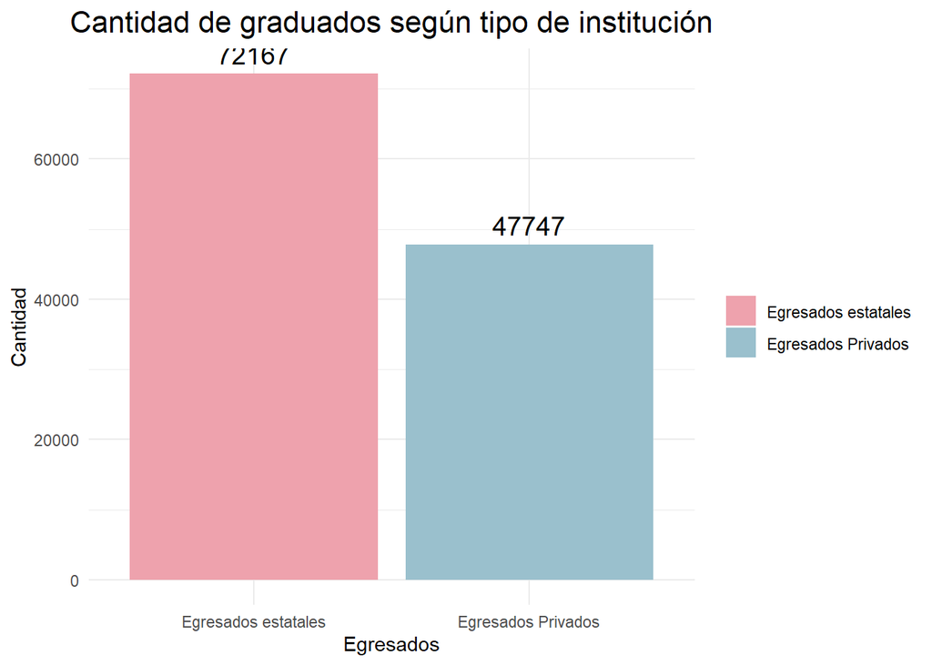

```r
# CUAL ES LA DIFERENCIA ENTRE CANTIDAD DE GRADUADOS EN UNIVERSIDADES PUBLICAS Y PRIVADAS - CAMI CON EL DE CHEQUEADO
library(readxl)
datos_chequeado <- read_excel("Universidades - egresados.xlsx")
library(tidyverse)

#Esto se encarga de filtrar la cantidad de egresados en universidades privadas
egresados_privadas <-  datos_chequeado %>%
  filter(`Año Informado` == 2020,
         `Régimen` == "Privado",
         `Tipo Institución` == "Universidad") %>%
   summarise(total_egresados_privadas = sum(Egresados, na.rm = TRUE)) %>%
  pull(total_egresados_privadas)

# sto se encarga de filtrar la cantidad de egresados en universidades ESTATALES
egresados_estatales <- datos_chequeado %>%
  filter(`Año Informado` == 2020,
         `Régimen` == "Estatal",
         `Tipo Institución` == "Universidad") %>%
  summarise(total_egresados_estatales = sum(Egresados, na.rm = TRUE)) %>%
  pull(total_egresados_estatales)

#install.packages("tidyverse")
library(tidyverse)
library(ggplot2)

# Aca creo el data frame para crear el grafico
df <- data.frame(
  Egresados_2020 = c("Egresados estatales","Egresados Privados"),
  Cantidad = c(egresados_estatales , egresados_privadas)
)

# GRAFICO SOBRE TOTAL DE EGRESADOS DE PRIVADAS VS PUBLICAS
ggplot(df, aes(x = Egresados_2020, y = Cantidad, fill = Egresados_2020)) +
  geom_bar(stat = "identity") +
  geom_text(aes(label = Cantidad), vjust = -0.5, size = 5) +
  scale_fill_manual(values = c("lightpink2", "lightblue3")) +
  labs(
    title = "Cantidad de graduados según tipo de institución",
    y = "Cantidad",
    x = "Egresados",
    fill = NULL
  ) +
  theme_minimal() +
  theme(plot.title = element_text(size = 16, hjust = 0.5))
```

### TOP 10 CARRERAS CON MÁS GRADUADOS

Para ampliar la información, nos hemos preguntado ¿ cuáles son las carreras con más cantidad de graduados? para responder a ello, hemos escogido las **top 10 carreras con más cantidad de graduados** y hemos adicionado el total por cada una de ellas, esto es a nivel nacional, según datos del 2020.

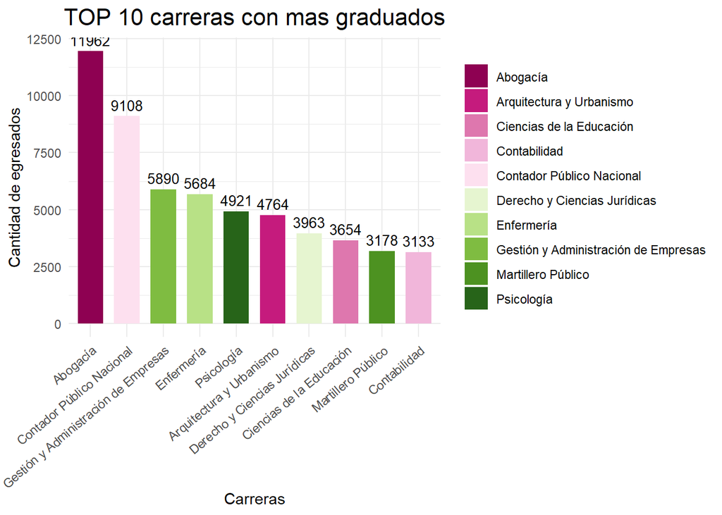

```r
#cantidad de graduados por carrera
graduadosxcarrera<- datos_chequeado %>%
  filter(`Año Informado` == 2020,)%>%
  arrange(desc(Egresados))%>%
  slice(2:11)%>%
  pull("Egresados")


datosxcarrera <- datos_chequeado %>%
  filter(`Año Informado` == 2020,
         `Carrrera` != "Carrera No Definida") %>%
  group_by(Carrrera) %>%
  summarise(graduadosxcarrera = sum(Egresados)) %>%
  arrange(desc(graduadosxcarrera)) %>%
  slice(1:10)  # Top 10 carreras

#GRAFICO DE CANTIDAD DE TOP CARRRERAS CON MAS GRADUADOS
library(RColorBrewer)

ggplot(datosxcarrera, aes(x = reorder(Carrrera, -graduadosxcarrera),
                          y = graduadosxcarrera, fill = Carrrera)) +
  geom_bar(stat = "identity", width = 0.7) +
  geom_text(aes(label = graduadosxcarrera),
            vjust = -0.5,
            color = "black",
            size = 3.5) +
  scale_fill_brewer(palette = "PiYG") +
  labs(title = "TOP 10 carreras con mas graduados",
       y = "Cantidad de egresados",
       x = "Carreras",
       fill= NULL
  ) +
  theme_minimal() +
  theme(axis.text.x = element_text(angle = 40, hjust = 1)) +
  theme(plot.title = element_text(size = 16, hjust = 0.5))
```

### RELACION GÉNERO - CANTIDAD DE GRADUADOS - TIPO DE INSTITUCIÓN

A continuación, realizamos un pequeño análisis respecto a la cantidad de egresados, su género (mujer u hombre) y el tipo de institucion de la cual proviene, ya sea universidad pública o privada. El objetivo de esto es ver si hay más egresados del género femenino o masculino. El primer gráfico que veremos será aquel proveniente de las **universidades públicas**:

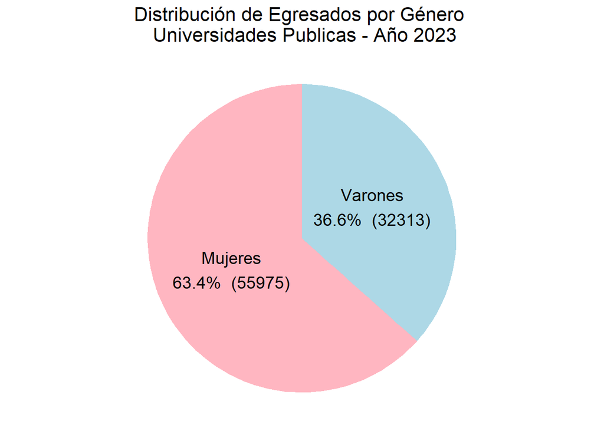

```r
#De aca obtengo los datos
data_2023 <- read_excel("2.1 Pregrado y Grado Gestión Estatal 2023.xlsx", sheet ="C2.1.5b",skip=2)

# En el siguiente grafico demuestro la distribucion por genero de los egresados en las universidades PUBLICAS
#Defino las variables (los datos los obtuve directamente del anuario, alli se encuentran ya detallados)
#Los podemos ver en el excel "2.1 Pregrado y Grado Gestión Estatal 202" hoja:"C2.1.5
total_egresados_publicas <- 88288
mujeres_porcentaje_publicas <- 63.4
varones_porcentaje_publicas <- 36.6

#Obtengo el total real a partir de los datos del porcentaje
total_mujeres_publicas <- (total_egresados_publicas * mujeres_porcentaje_publicas)/100
total_varones_publicas <- (total_egresados_publicas * varones_porcentaje_publicas)/100


#creo el data frame que me va a permitir crear el grafico
df_porcentajes_publicas <- data.frame(
  Genero_publicas = c("Mujeres","Varones"),
  Porcentaje_publicas = c(mujeres_porcentaje_publicas,varones_porcentaje_publicas),
  Total_publicas = c(total_mujeres_publicas,total_varones_publicas)
) %>%
  mutate(
    Etiqueta_publicas = paste0(Genero_publicas, "\n", Porcentaje_publicas, "%  (", round(Total_publicas), ")")
  )

# ACA CREO EL GRAFICO DE PORCIONES PARA VER LA DISTRIBUCION X GENERO EN UNIVERSIDADES PUBLICAS
distribucion_publicas <- ggplot(df_porcentajes_publicas,aes( x = "", y = Porcentaje_publicas, fill = Genero_publicas)) +
   geom_bar(stat = "identity", width = 1) +
   coord_polar("y") +
   geom_text(aes(label = Etiqueta_publicas),
            position = position_stack(vjust = 0.5),
            color = "Black", size = 5) +
   scale_fill_manual(values = c("lightpink", "lightblue")) +
   labs(title = "Distribución de Egresados por Género \n Universidades Publicas - Año 2023") +
   theme_void() +
   theme(plot.title = element_text(hjust = 0.5, size = 16),
         legend.position = "none")

#Con esto podemos ejecutar el grafico directamente
distribucion_publicas
```

A continuación, el gráfico relacionado a las **universidades privadas**:

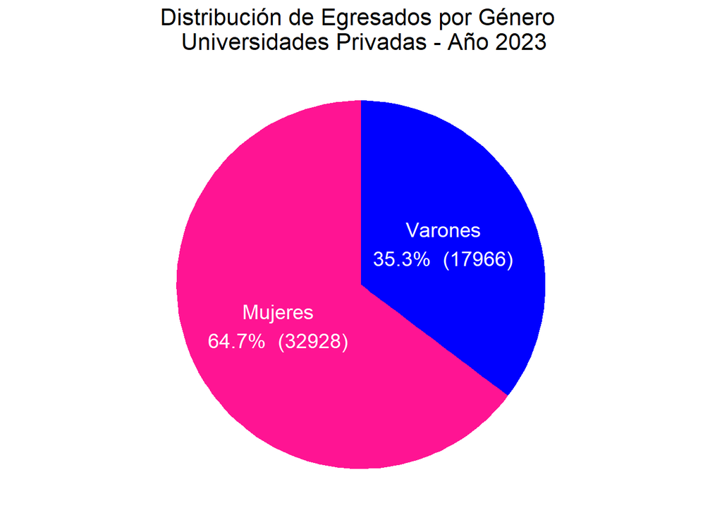

```r
# ------- PARA LAS UNIVERSIDADES PRIVADAS

total_egresados_privadas <- 50894
mujeres_porcentaje_privadas <- 64.7
varones_porcentaje_privadas <- 35.3

total_mujeres_privadas <- (total_egresados_privadas * mujeres_porcentaje_privadas)/100
total_varones_privadas <- (total_egresados_privadas * varones_porcentaje_privadas)/100

df_porcentajes_privadas <- data.frame(
  Genero_privadas = c("Mujeres","Varones"),
  Porcentaje_privadas = c(mujeres_porcentaje_privadas,varones_porcentaje_privadas),
  Total_privadas = c(total_mujeres_privadas,total_varones_privadas)
) %>%
  mutate(
    Etiqueta_privadas = paste0(Genero_privadas, "\n", Porcentaje_privadas, "%  (", round(Total_privadas), ")")
  )

# ACA CREO EL GRAFICO DE PORCIONES PARA VER LA DISTRIBUCION X GENERO EN UNIVERSIDADES PUBLICAS
distribucion_privadas <- ggplot(df_porcentajes_privadas,aes( x = "", y = Porcentaje_privadas, fill = Genero_privadas)) +
  geom_bar(stat = "identity", width = 1) +
  coord_polar("y") +
  geom_text(aes(label = Etiqueta_privadas),
            position = position_stack(vjust = 0.5),
            color = "White", size = 5) +
  scale_fill_manual(values = c("deeppink", "blue")) +
  labs(title = "Distribución de Egresados por Género \n Universidades Privadas - Año 2023") +
  theme_void() +
  theme(plot.title = element_text(hjust = 0.5, size = 16),
        legend.position = "none")

#CON ESTO EJECUTO EL GRAFICO
distribucion_privadas
```

Por último, el siguiente gráfico es una pequeña **comparación de la cantidad de egresados según género y tipo de universidad**, como podemos apreciar, hay una mayor cantidad de graduadas mujeres, y este patrón se da tanto en universidades públicas como privadas:

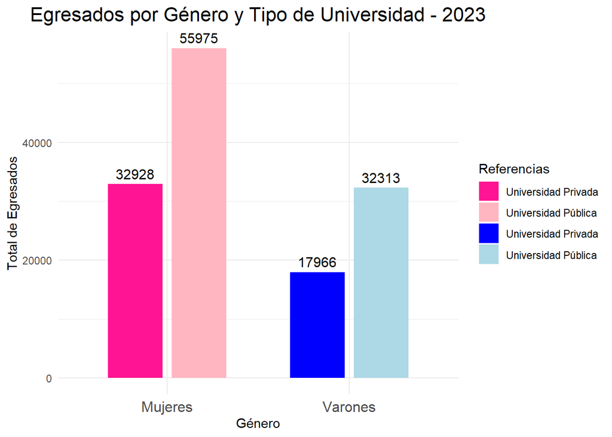

```r
# ---- GRAFICO COMPARATIVO

#LOS DATOS QUE TENIAMOS ANTES SOLO QUE REDONDEADOS

total_mujeres_publicas2 <- round((total_egresados_publicas * mujeres_porcentaje_publicas)/100)
total_varones_publicas2 <- round((total_egresados_publicas * varones_porcentaje_publicas)/100)
total_mujeres_privadas2 <- round((total_egresados_privadas * mujeres_porcentaje_privadas)/100)
total_varones_privadas2 <- round((total_egresados_privadas * varones_porcentaje_privadas)/100)



# CREO EL DATAFRAME CON LOS DATOS QUE VOY A USAR EN EL GRAFICO
df_comparativo2 <- data.frame(
  Genero2 = c("Mujeres", "Mujeres", "Varones", "Varones"),
  Tipo2 = c("Pública", "Privada", "Pública", "Privada"),
  Total2 = c(total_mujeres_publicas2, total_mujeres_privadas2, total_varones_publicas2, total_varones_privadas2),
  Grupo2 = c("Mujeres Pública", "Mujeres Privada", "Varones Pública", "Varones Privada"),
  colores_por_grupo2 <- c( "Mujeres Pública" = "lightpink", "Mujeres Privada" = "deeppink",
                           "Varones Pública" = "lightblue", "Varones Privada" = "blue" )
)

# creo el grafico comparativo
grafico_comparativo <- ggplot(df_comparativo2, aes(x = Genero2, y = Total2, fill = Grupo2)) +
  geom_bar(stat = "identity", position = position_dodge(width = 0.7), width = 0.6) +
  geom_text(aes(label = Total2), position = position_dodge(width = 0.7),vjust = -0.5, size = 4) +
  scale_fill_manual(values = colores_por_grupo2,labels = c(
      "Mujeres Pública" = "Universidad Pública",
      "Mujeres Privada" = "Universidad Privada",
      "Varones Pública" = "Universidad Pública",
      "Varones Privada" = "Universidad Privada"
    ),
    name = "Referencias") +
  labs(
    title = "Egresados por Género y Tipo de Universidad - 2023",
    x = "Género",
    y = "Total de Egresados") +
  theme_minimal() +
  theme(
    plot.title = element_text(hjust = 0.5, size = 16),
    axis.text.x = element_text(size = 12)
)


#CON ESTO EJECUTO EL GRAFICO
grafico_comparativo
```

### ¿Cómo afecta la modalidad de estudio a la cantidad de egresados?

Hemos decidido analizar qué tipo de modalidad elegida por los estudiantes, siendo estas presencial o virtual, genera más cantidad de graduados. A partir de este análisis, hemos creado el siguiente gráfico comparativo:

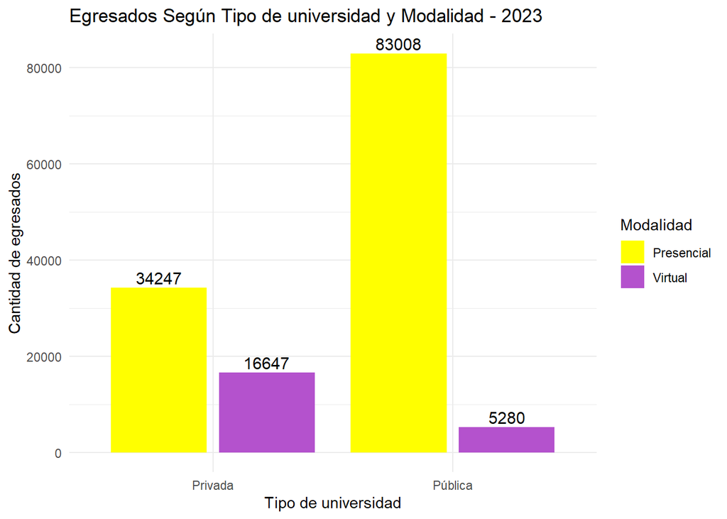

```r
# los datos los obtuvimos de:
#data_2023_privadas_modalidad <- read_excel("2.2 Pregrado y Grado Gestión Privada 2023.xlsx", sheet = "C 2.2.26.a")
#data_2023_publicas_modalidad <- read_excel("2.2 Pregrado y Grado Gestión Estatal 2023.xlsx", sheet = "C 2.1.26.a")


# El data frame que vamos a utilizar para crear nuestro gráfico
df_modalidades <- data.frame(
  Universidad = rep(c("Pública", "Privada"), each = 2),
  Modalidad   = rep(c("Presencial", "Virtual"), times = 2),
  Cantidad    = c(83008, 5280, 34247, 16647)
)

# El gráfico
grafico_modalidades <- ggplot(df_modalidades, aes(x = Universidad, y = Cantidad, fill = Modalidad)) +
  geom_bar(stat = "identity", position = position_dodge(width = 0.9), width = 0.8) +
  scale_fill_manual( values = c( "Presencial" = "yellow", "Virtual"    = "mediumorchid3")) +
  geom_text(
    aes(label = Cantidad),
    position = position_dodge(width = 0.9),
    vjust = -0.3,
    size = 4
  ) +
  labs(
    title = "Egresados Según Tipo de universidad y Modalidad - 2023",
    x = "Tipo de universidad",
    y = "Cantidad de egresados",
    fill  = "Modalidad"
  ) +
  theme_minimal()

#Con esto ejecutamos el grafico
grafico_modalidades
```

Como podemos ver, la virtualidad tiene un mayor impacto en las universidades privadas, en donde el 32,70% de su alumnado se egresa bajo esta modalidad, mientras que el 67,30% restante bajo la presencialidad. Sin embargo esto cambia drásticamente en las universidades públicas, donde solamente el 5,98% de los egresados es proveniente de la modalidad virtual, frente a un 94,02% restante, que eligió la presencialidad.

### Reinscriptos en universidades nacionales de gestión estatal

Se analiza la cantidad de reinscriptos en universidades **nacionales de gestión estatal** en los años **2020, 2021 y 2023** a partir de los anuarios estadísticos del sistema universitario.

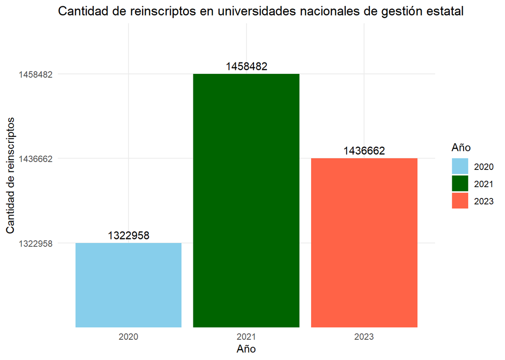

```r
library(readxl)
library(dplyr)
library(ggplot2)

# Leer datos
data_2020 <- read_excel("1.2 Indicadores 2020.xlsx", sheet = "C 1.2.1a", skip = 2)
data_2021 <- read_excel("1.2 Indicadores 2021.xlsx", sheet = "C 1.2.1a", skip = 2)
data_2023 <- read_excel("1.2 Indicadores 2023.xlsx", sheet = "C 1.2.1a", skip = 2)

# Filtrar y extraer los valores de reinscriptos desde la 6ta columna
ri_2020 <- data_2020 %>%
  filter(Institución == "Total Universidades Nacionales") %>%
  pull(6)

ri_2021 <- data_2021 %>%
  filter(Institución == "Total Universidades Nacionales") %>%
  pull(6)

ri_2023 <- data_2023 %>%
  filter(Institución == "Total Universidades Nacionales") %>%
  pull(6)

# Creo un data frame con los datos
reinscriptos <- data.frame(
  Año = c("2020", "2021", "2023"),
  Reinscriptos = c(ri_2020, ri_2021, ri_2023)
)

# Creo el gráfico
ggplot(reinscriptos, aes(x = Año, y = Reinscriptos, fill = Año)) +
  geom_bar(stat = "identity") +
  geom_text(aes(label = Reinscriptos), vjust = -0.5) +
  labs(
    title = "Cantidad de reinscriptos en universidades nacionales de gestión estatal",
    x = "Año",
    y = "Cantidad de reinscriptos"
  ) +
  scale_fill_manual(values = c("2020" = "skyblue", "2021" = "darkgreen", "2023" = "tomato")) +
  theme_minimal()
```

### Cantidad de egresados de Universidades Nacionales y Provinciales.

### A partir del siguiente gráfico se hace un analisis de la cantidad de **egresados** de los **años 2021 y 2023** en Universidades tanto Nacionales como provinciales.

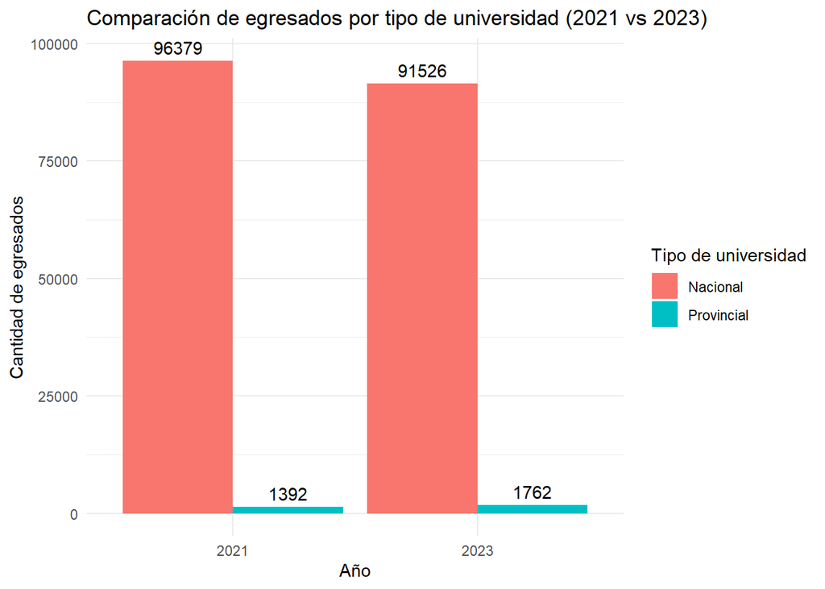

```r
# Cargo paquetes necesarios
library(readxl)
library(dplyr)
library(ggplot2)

# Cargo datos desde la hoja correspondiente
datos_2021 <- read_excel("1.2 Indicadores 2021.xlsx", sheet = "C 1.2.1a", skip = 2)
datos_2023 <- read_excel("1.2 Indicadores 2023.xlsx", sheet = "C 1.2.1a", skip = 2)
# Proceso datos de 2021
egresados_2021 <- datos_2021 %>%
  select(Institución, `Egresadas/os (EGR)`) %>%
  filter(!is.na(`Egresadas/os (EGR)`)) %>%
  mutate(
    `Egresadas/os (EGR)` = as.numeric(gsub("[^0-9]", "", `Egresadas/os (EGR)`)),
    tipo = case_when(
      grepl("Nacional", Institución) ~ "Nacional",
      grepl("Provincial", Institución) ~ "Provincial",
      TRUE ~ NA_character_
    ),
    año = 2021
  ) %>%
  filter(!is.na(tipo)) %>%
  group_by(año, tipo) %>%
  summarise(Egresados = sum(`Egresadas/os (EGR)`, na.rm = TRUE), .groups = "drop")

# Proceso datos de 2023
egresados_2023 <- datos_2023 %>%
  select(Institución, `Egresados (EGR)`) %>%
  filter(!is.na(`Egresados (EGR)`)) %>%
  mutate(
    `Egresados (EGR)` = as.numeric(gsub("[^0-9]", "", `Egresados (EGR)`)),
    tipo = case_when(
      grepl("Nacional", Institución) ~ "Nacional",
      grepl("Provincial", Institución) ~ "Provincial",
      TRUE ~ NA_character_
    ),
    año = 2023
  ) %>%
  filter(!is.na(tipo)) %>%
  group_by(año, tipo) %>%
  summarise(Egresados = sum(`Egresados (EGR)`, na.rm = TRUE), .groups = "drop")

# Uno todos los datos
egresados_comparados <- bind_rows(egresados_2021, egresados_2023)

# Creo gráfico de columnas agrupadas
ggplot(egresados_comparados, aes(x = factor(año), y = Egresados, fill = tipo)) +
  geom_bar(stat = "identity", position = "dodge") +
  geom_text(aes(label = Egresados), position = position_dodge(width = 0.9), vjust = -0.5) +
  labs(
    title = "Comparación de egresados por tipo de universidad (2021 vs 2023)",
    x = "Año",
    y = "Cantidad de egresados",
    fill = "Tipo de universidad"
  ) +
  theme_minimal()
```

### ¿Cómo varía la cantidad de egresados por área disciplinar?

A partir de los datos recolectados, se puede observar que la cantidad de egresados varía bastante según el área disciplinar. Algunas áreas, como *Ciencias de la Salud: Medicina*, tienen una cantidad muy alta de egresados tanto en universidades estatales como privadas, lo que indica una fuerte presencia en el sistema educativo. En cambio, áreas como *Arquitectura y Diseño* o *Biología* tienen cifras más bajas.

También se nota que en ciertas disciplinas, como *Economía y Administración*, el número de egresados en la gestión privada es incluso mayor que en la estatal. Este tipo de diferencias nos ayudan a entender cómo se distribuyen los egresos en función del tipo de institución y del interés que despierta cada carrera.

| Rama y disciplina | Años | Total gestión estatal | Total gestión privada | Total |
| --- | --- | --- | --- | --- |
| Ciencias aplicadas: arquitectura y diseño | 2020, 2021, 2023 | 141, 122, 249 | 28, 32, 21 | 593 |
| ciencias basicas: Biología | 2020, 2021, 2023 | 392, 363, 478 | 13, 24, 23 | 1293 |
| Ciencias de la salud: Medicina | 2020, 2021, 2023 | 1656, 1762, 4968 | 658, 778, 747 | 10569 |
| Ciencias humanas: Educacion | 2020, 2021, 2023 | 1364, 930, 1160 | 289, 264, 316 | 4323 |
| Ciencias sociales: Economía y administración | 2020, 2021, 2023 | 638, 930, 1121 | 1653, 1429, 2056 | 7827 |

### Ojiva

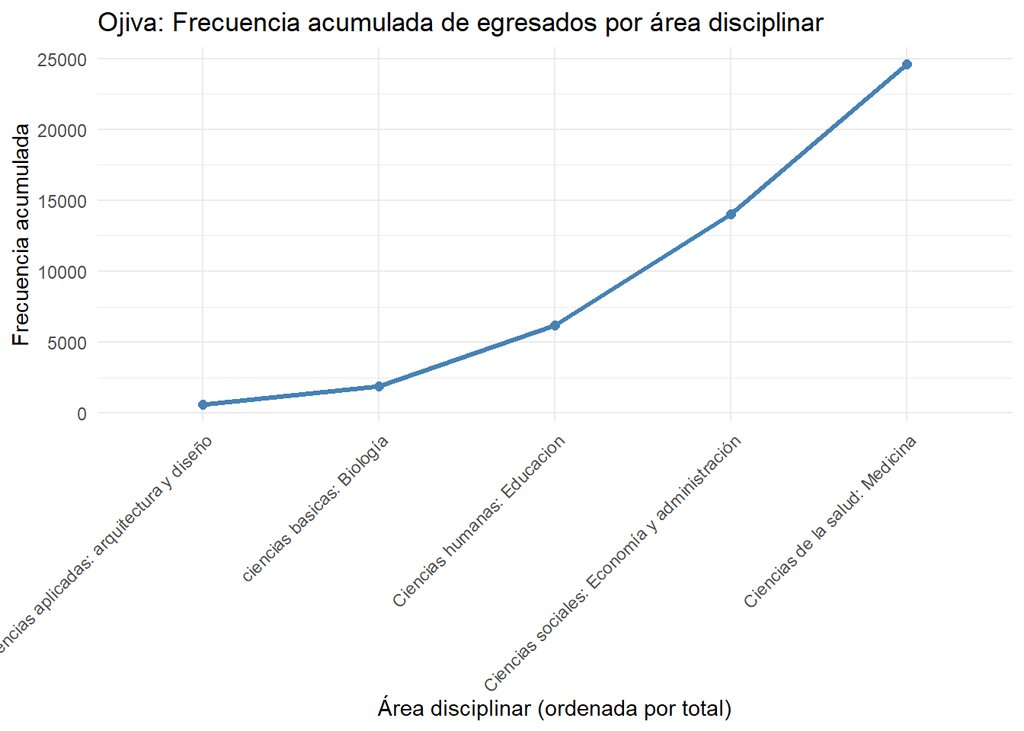

```r
library(dplyr)
library(ggplot2)

# Aseguramos que la columna Total sea numérica
egresados <- egresados %>%
  mutate(Total = as.numeric(Total)) %>%
  arrange(Total) %>%
  mutate(FrecuenciaAcumulada = cumsum(Total))

# Creamos el Ojiva
ggplot(egresados, aes(x = reorder(`Rama y disciplina`, Total), y = FrecuenciaAcumulada, group = 1)) +
  geom_line(color = "steelblue", size = 1.2) +
  geom_point(color = "steelblue", size = 2) +
  labs(
    title = "Ojiva: Frecuencia acumulada de egresados por área disciplinar",
    x = "Área disciplinar (ordenada por total)",
    y = "Frecuencia acumulada"
  ) +
  theme_minimal() +
  theme(axis.text.x = element_text(angle = 45, hjust = 1))
```

### Interpretación de la ojiva

La ojiva permite visualizar cómo se acumula el total de egresados por área disciplinar. Al ordenar las disciplinas de menor a mayor según su cantidad de egresados, observamos que unas pocas áreas concentran una gran parte del total acumulado. Por ejemplo, Ciencias de la Salud: Medicina aporta un incremento considerable en la curva, mientras que disciplinas como Arquitectura y Diseño o Biología generan un aumento más gradual.

Este tipo de representación es útil porque permite identificar rápidamente qué áreas tienen mayor peso en el total de egresados. Desde una perspectiva de Ciencia de Datos, la ojiva ayuda a detectar posibles desequilibrios en la distribución y podría servir como base para futuros análisis más profundos o recomendaciones educativas.

## 📊 Datos de egresados

### 📊 Datos de egresados

```r
egresados <- data.frame(
  Año = c(2020, 2021, 2023),
  Total = c(139182, 142826, 139182)
)

egresados
```

```
##    Año  Total
## 1 2020 139182
## 2 2021 142826
## 3 2023 139182
```

### 📈 Cálculo de cambios entre años

```r
egresados$Cambio_Absoluto <- c(NA, diff(egresados$Total))
egresados$Cambio_Porcentaje <- c(NA, round((diff(egresados$Total) / head(egresados$Total, -1)) * 100, 2))

egresados
```

```
##    Año  Total Cambio_Absoluto Cambio_Porcentaje
## 1 2020 139182              NA                NA
## 2 2021 142826            3644              2.62
## 3 2023 139182           -3644             -2.55
```

### 📊 Gráfico comparativo de egresados

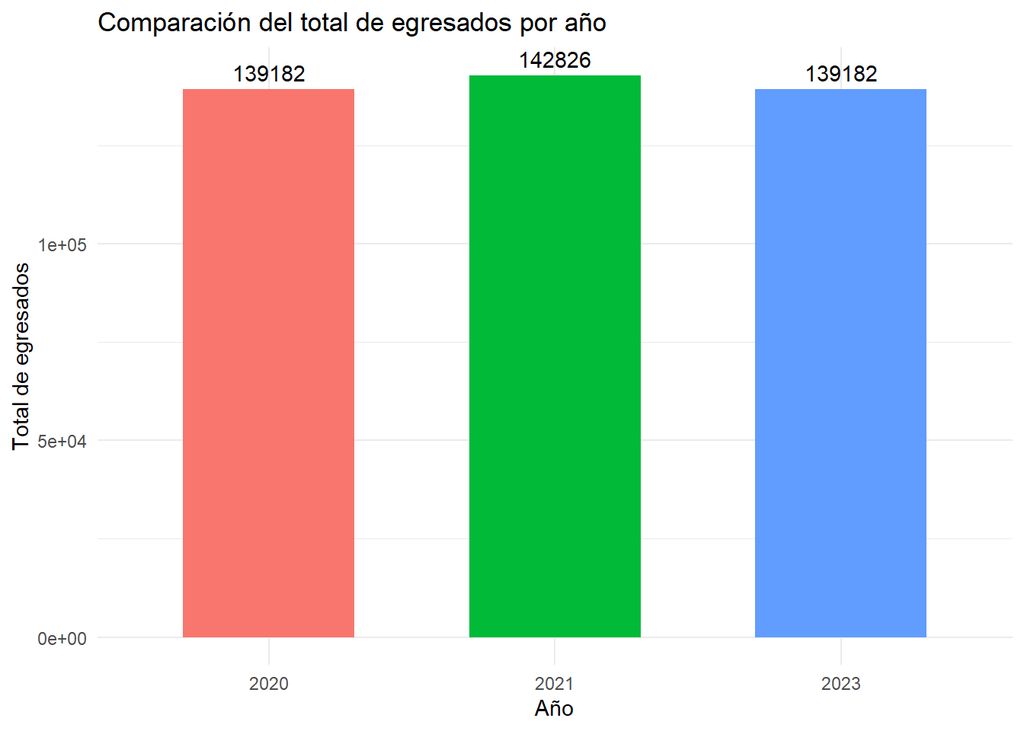

```r
ggplot(egresados, aes(x = factor(Año), y = Total, fill = factor(Año))) +
  geom_bar(stat = "identity", width = 0.6) +
  labs(title = "Comparación del total de egresados por año",
       x = "Año",
       y = "Total de egresados") +
  theme_minimal() +
  theme(legend.position = "none") +
  geom_text(aes(label = Total), vjust = -0.5)
```

### Análisis del cambio en el número total de egresados

Entre 2021 y 2023, el total de egresados pasó de 142826 a 139182, lo que representa una disminución de 3644 egresados (-2.55%).

### Cómo afecta a la cantidad de graduados el nivel academico de sus padres ?

```r
#llamamos a las librarias que podemos llegar a utilizar
library(readxl)
library(ggplot2)
library(dplyr)
library(tidyr)


# nivel academico de la madre del graduado
nivel_madre <- read_excel("2.1 Pregrado y Grado Gestión Estatal 2023.xlsx", sheet = "C.2.1.32", skip=4 )

#reorganizamos y filtramos el dataset
colnames(nivel_madre)[1] <- "Institucion"
nivel_madre_limpio <- nivel_madre %>%

  filter(Institucion == "Total Universidades Nacionales") %>%
  pivot_longer(
    cols = -Institucion,
    names_to = "Nivel_academico",
    values_to = "Cantidad") %>%

  mutate(
    Cantidad = as.numeric(Cantidad),
    Nivel_academico_sesgo = trimws(tolower(Nivel_academico)),
    Padre_Madre = "Madre") %>%

#limpiamos las columnas que no nos interesan
  filter(!Nivel_academico_sesgo %in% c("total", "no sabe", "ndi"))
```

```r
library(readxl)
library(dplyr)
library(tidyr)

# nivel academico del Padre del graduado

#primer paso leemos el dataset y llamamos nuestra hoja correspondiente.
nivel_padre <- read_excel("2.1 Pregrado y Grado Gestión Estatal 2023.xlsx", sheet = "C.2.1.33", skip=4 )
colnames(nivel_padre)[1] <- "Institucion"
nivel_padre_limpio <- nivel_padre %>%
  filter(Institucion == "Total Universidades Nacionales") %>%
  pivot_longer(
    cols = -Institucion,
    names_to = "Nivel_academico",
    values_to = "Cantidad"
  ) %>%
  mutate(
    Cantidad = as.numeric(Cantidad),
    Nivel_academico_sesgo = trimws(tolower(Nivel_academico)),
    Padre_Madre = "Padre") %>%
  filter(!Nivel_academico_sesgo %in% c("total", "no sabe", "ndi"))
```

### 📊 Unimos los dos codigos para luego graficar la comparacion ver juntos ambos resultados

```r
library(readxl)
library(dplyr)
library(tidyr)

#asignamos la comparación

comparativo <- bind_rows(nivel_madre_limpio, nivel_padre_limpio)

# Gráficamos
ggplot(comparativo, aes(x = reorder(Nivel_academico, -Cantidad), y = Cantidad, fill = Padre_Madre)) +
  geom_col(position = "dodge") +
  geom_text(aes(label = Cantidad), position = position_dodge(width = 0.9), vjust = -0.3, size = 3) +
  theme_minimal() +
  theme(axis.text.x = element_text(angle = 45, hjust = 1)) +
  labs(
    title = "Nivel academico del padre y la madre del graduado - Universidades Nacionales (2023)",
    x = "Nivel academico",
    y = "Cantidad de egresados",
    fill = "padre y madre"
  )
```

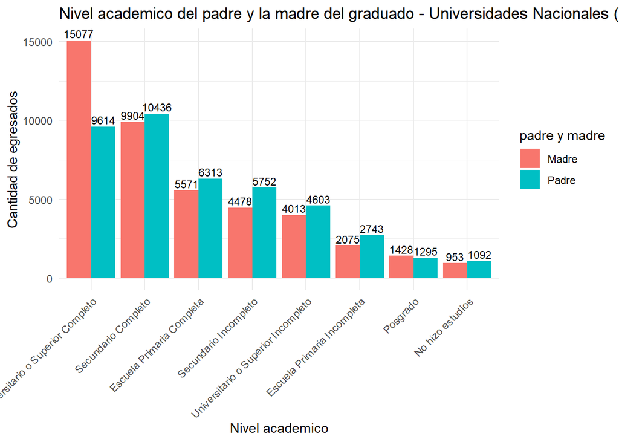

[figure not shown]